# Project Code

Mindful Masterminds of the Statistical Sciences

Author

Vincent Chen, Will Krew, Daniel Gold, and Andrew Metzger

Published

December 4, 2023

Abstract

*This file contains the code for the project on NFL offensive data EDA, as part of the STAT303-1 course in Fall 2023*.

## 1 Data quality check / cleaning / preparation

Put code with comments. The comments should explain the code such that it can be easily understood. You may put text *(in a markdown cell)* before a large chunk of code to explain the overall purpose of the code, if it is not intuitive. **Put the name of the person / persons who contributed to each code chunk / set of code chunks.** An example is given below.

### 1.1 Distribution of variables

*By All*

```python
import pandas as pd
import matplotlib.pyplot as plt
import seaborn as sns
import numpy as np
data = pd.read_csv('nfl_offensive_stats.csv')
```

##### 1.1.0.1 game_id

Each game in the dataset has its own game_id, rows with the same game_id represent the same game

```python
print('Number of unique values:', data.game_id.nunique())
print('Number of missing values:', data.game_id.isnull().sum())
data.game_id.value_counts()[:4]
```

```
Number of unique values: 820
Number of missing values: 0
```

```
202010110sfo    29
202010180pit    29
202010180tam    29
202111140rai    29
Name: game_id, dtype: int64
```

##### 1.1.0.2 team

Indicates the team of the player

```python
print('Number of unique values:', data.team.nunique())
print('Number of missing values:', data.team.isnull().sum())
data.team.value_counts()[:4]
```

```
Number of unique values: 32
Number of missing values: 0
```

```
KAN    743
TEN    693
GNB    690
TAM    687
Name: team, dtype: int64
```

##### 1.1.0.3 position

Indicates the position of the player

```python
print('Number of unique values:', data['position '].nunique())
print('Number of missing values:', data['position '].isnull().sum())
data['position '].value_counts()[0:4]
```

```
Number of unique values: 28
Number of missing values: 0
```

```
WR    7904
TE    4711
RB    4447
QB    1994
Name: position , dtype: int64
```

##### 1.1.0.4 home_team

indicates the home team for the game of that row’s game_id

```python
print('Number of unique values:', data.home_team.nunique())
print('Number of missing values:', data.home_team.isnull().sum())
data.home_team.value_counts()[0:4]
```

```
Number of unique values: 32
Number of missing values: 0
```

```
KAN    823
GNB    686
NOR    678
TEN    671
Name: home_team, dtype: int64
```

##### 1.1.0.5 vis_team

indicates the away team for the game of that row’s game_id

```python
print('Number of unique values:', data.vis_team.nunique())
print('Number of missing values:', data.vis_team.isnull().sum())
data.vis_team.value_counts()[0:4]
```

```
Number of unique values: 32
Number of missing values: 0
```

```
TAM    709
SFO    679
TEN    663
BUF    660
Name: vis_team, dtype: int64
```

##### 1.1.0.6 Surface

Indicates the field surface for the row’s game_id

```python
print('Number of unique values:', data.Surface.nunique())
print('Number of missing values:', data.Surface.isnull().sum())
data.Surface.value_counts()
```

```
Number of unique values: 8
Number of missing values: 0
```

```
grass         9002
grass         3130
fieldturf     2260
fieldturf     2144
astroturf     1360
matrixturf    1082
sportturf      753
a_turf         242
Name: Surface, dtype: int64
```

##### 1.1.0.7 Vegas_Favorite

Indicates the team that sportsbooks projected to win the game

```python
print('Number of unique values:', data.Vegas_Favorite.nunique())
print('Number of missing values:', data.Vegas_Favorite.isnull().sum())
print(pd.concat([data.Vegas_Favorite.value_counts()[:4],data.Vegas_Favorite.value_counts()[32:33]]))
```

```
Number of unique values: 33
Number of missing values: 46
KAN                    1318
GNB                    1040
TAM                    1002
LAR                     974
ERROR - abbrev_team      70
Name: Vegas_Favorite, dtype: int64
```

### 1.2 Data cleaning

*By Andrew Metzger and Daniel Gold*

```python
data.loc[data.Vegas_Favorite=='ERROR - abbrev_team','game_id'].unique() #Prints out the game ids of all of the error missing team for vegas favorite which will be manually changed in the nect section
```

```
array(['202012020pit', '202012070pit', '202012080rav'], dtype=object)
```

```python
#removed the extra space from the position column
data.rename(columns={'position ':'position'},inplace=True)
#removed the extra space from some of the entries of the surface column
data.Surface=data.Surface.apply(lambda x: 'fieldturf' if 'fieldturf' in x else 'grass' if 'grass' in x else x)
data.loc[data[data.Vegas_Favorite.isnull()].index,'Vegas_Favorite']='None' #Changed the null values in Vegas_Favorite to 'None' as neither team is the favorite to win
data.loc[data.game_id=='202012020pit','Vegas_Favorite'] = 'PIT' #Googled and put in the vegas favorite for the missing value for this game
data.loc[data.game_id=='202012070pit','Vegas_Favorite'] = 'PIT' #Googled and put in the vegas favorite for the missing value for this game
data.loc[data.game_id=='202012080rav','Vegas_Favorite'] = 'BAL' #Googled and put in the vegas favorite for the missing value for this game
```

### 1.3 Data preparation

*By All*

The following data preparation steps helped us to prepare our data for implementing various modeling / validation techniques:

```python
######---------------Creating new variables----------------#########

data['score']=data.apply(lambda x: x.home_score if x.team==x.home_team else x.vis_score,axis=1) #Score of the team of a player in a game
data['score_diff']=data.apply(lambda x: x.home_score-x.vis_score if x.team==x.home_team else x.vis_score-x.home_score,axis=1) #Score of the team of a player minus score of other team in a game
data['Vegas_Line']=data.apply(lambda x:x.Vegas_Line if x.Vegas_Favorite==x.team else -x.Vegas_Line,axis=1) #Changes teams that are not favored to win to a positive vegas line (as +3.5 means you are supposed to lose by 3.5 points)
data['favorite']=data.apply(lambda x: 'yes' if x.Vegas_Line < 0 else 'push' if x.Vegas_Line==0 else 'no',axis=1) #Categorical variable that determines if a team is favorited to win
data['win'] = data.apply(lambda x: 'win' if x.score_diff>0 else 'tie' if x.score_diff==0 else 'loss',axis=1) #Categorical variable that determines if a team won the game
data['covered'] = data.apply(lambda x:'yes' if x.Vegas_Line+x.score_diff>0 else 'push' if x.Vegas_Line + x.score_diff==0 else 'no',axis=1) #Categorical variable to determine if a team covered the spread (i.e. if vegas line -3, team wins by than 3 points or if vegas line +3, team loses by less than 3 or wins)
#creating a column to store the sum of passing and rushing yards
data['Rushing+Passing']=data.pass_yds+data.rush_yds
#creating a column to store the sum of rushing and receiving yards
data['Rushing+Receiving']=data.rush_yds+data.rec_yds
#creating a Boolean column that indicates whether the player is playing home or not
data['player_is_home'] = data['home_team'] == data['team']
#the next column indicates whether the player is home or away: conveys equivalent information as previous column
data['home_or_away'] = data['player_is_home'].apply(lambda x: 'home' if x==True else 'away')
#creating a column that indicates the difference of scores between home and away team
data['h-a_score'] = data['home_score']-data['vis_score']
```

```python
######-----Standardizing the dataset ----------------------#########
```

## 2 Exploratory data analysis

Put code with comments. The comments should explain the code such that it can be easily understood. You may put text *(in a markdown cell)* before a large chunk of code to explain the overall purpose of the code, if it is not intuitive. **Put the name of the person / persons who contributed to each code chunk / set of code chunks.**

### 2.1 Analysis 1

*By Vincent Chen*

#### 2.1.1 1) Code section for whether home vs. away has an association with individual player performance

```python
key_position_stats = data.loc[data['position'].isin(['QB', 'RB', 'WR', 'TE']), :]
# 'QB', 'RB', 'WR', 'TE' are the most important positions
```

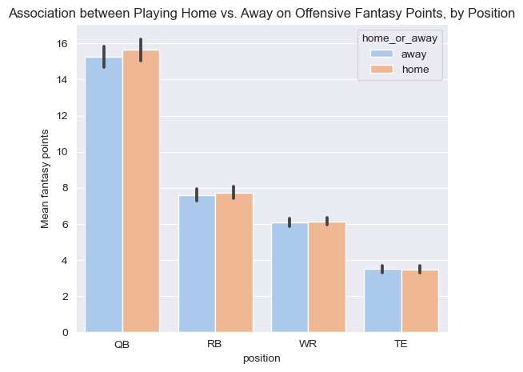

```python
#plotting the association between playing home and away on offensive fantasy points per player, by position.
    # 'Total_SDP' is an offensive fantasy point measure.

sns.set_style('darkgrid')
plt.figure(figsize = (6,5))
a = sns.barplot(data = key_position_stats, x = 'position', y = 'Total_SDP', hue = 'home_or_away', palette = 'pastel');
a.set_ylabel('Mean fantasy points');
a.set_title('Association between Playing Home vs. Away on Offensive Fantasy Points, by Position');
```

#### 2.1.2 2) Effect of home vs. away on team performance

```python
#firstly, lets aggregate it to a game by game basis
game_stats = (data.groupby('game_id').mean()).drop(columns = ['score_diff', 'score'])   #dropping irrelevant columns for now
```

```python
#some basic statistics to start us off
print(game_stats['h-a_score'].median())
print(game_stats['h-a_score'].mean())
print(np.percentile(game_stats['h-a_score'], 25))
print(np.percentile(game_stats['h-a_score'], 75))
```

```
1.0
0.675609756097561
-7.0
10.0
```

Based on the above, since the median of home score - away score is 1, with a mean of 0.675, and the 75 percentile is 10 while the 25 percentile is -7, it seems like home teams do perform slightly better on average than away teams.

The following code represents the percentage of games where the home team wins vs the away team wins.

```python
game_stats[game_stats['h-a_score']>0].shape[0]/game_stats.shape[0]
```

```
0.5097560975609756
```

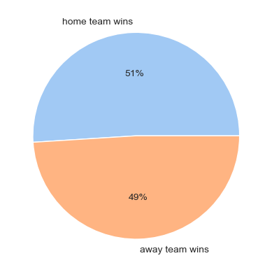

```python
#this plot indicates the rough percentage of games where home team wins vs. visting team wins
plt.pie([51, 49], labels= ['home team wins','away team wins'], colors = sns.color_palette('pastel')[0:5], autopct='%.0f%%');
```

The following code plots the distribution of score differences between home and away teams. Understanding the score distribution gives a more in depth understanding.

```
the median score differnece is 1.0
the mean score difference is 0.675609756097561
the 25th percentile is -7.0
the 75th percentile is 10.0
```

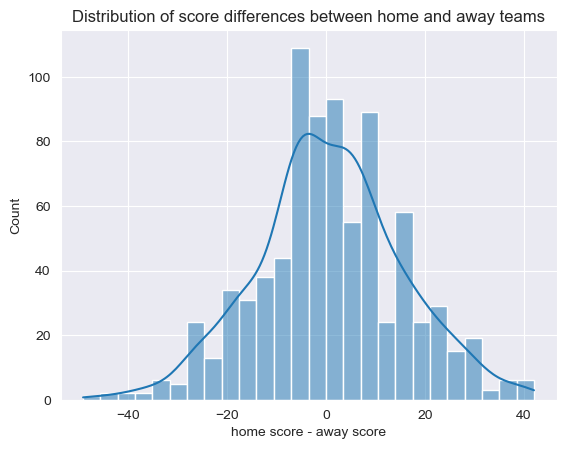

```python
#this is the following code for plotting the distribution of score differences between home and away teams

sns.histplot(data = game_stats, x = 'h-a_score', kde= True, label = 'home score - away score')
plt.xlabel('home score - away score');
plt.title('Distribution of score differences between home and away teams');
print('the median score differnece is ' + str(game_stats['h-a_score'].median()))
print('the mean score difference is ' + str(game_stats['h-a_score'].mean()))
print('the 25th percentile is ' + str(np.percentile(game_stats['h-a_score'], 25)))
print('the 75th percentile is ' + str(np.percentile(game_stats['h-a_score'], 75)))
```

The following will be the same distribution plot, but binned in a way to better shows the trends.

```python
min(game_stats['h-a_score']), max(game_stats['h-a_score'])   #tells us minimum and max score for bins
```

```
(-49.0, 42.0)
```

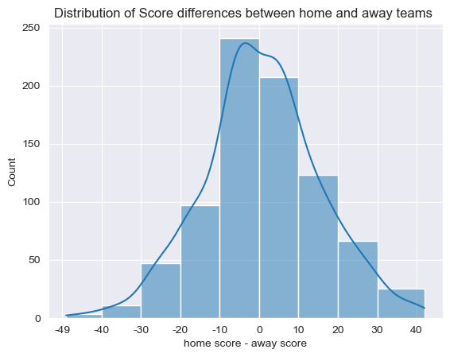

```python
a = sns.histplot(data = game_stats, bins = [-49, -40, -30, -20, -10, 0,10, 20, 30, 42], x = 'h-a_score', kde = True, label = 'home score - away score')
a.set_xticks(ticks = [-50, -40, -30, -20, -10, 0, 10, 20, 30, 40], labels = [-49, -40, -30, -20, -10, 0, 10, 20, 30, 40]);
a.set_title('Distribution of Score differences between home and away teams ');
a.set_xlabel('home score - away score');
```

We observe that while home teams have a higher chance of willing by more than 10 points, home teams have a higher chance of losing by less than 10 points than are away teams. The following calculates specifically how more likely these values are

```python
#the first line is how much more likely a home team is to win by a large margin than away teams are
print((game_stats['h-a_score'] >= 10).sum()/(game_stats['h-a_score'] <= -10).sum())

#the next line is how much more likely a home team is to lose by a small margin (10 points) than away teams are
print(((game_stats['h-a_score'] > -10) & (game_stats['h-a_score'] < 0)).sum()/((game_stats['h-a_score'] < 10) & (game_stats['h-a_score'] > 0)).sum())
```

```
1.2159090909090908
1.0931372549019607
```

##### 2.1.2.1 Why do home teams lose by a small margin more often than away teams do? What are the specific statistics that are associated with this?

```python
#aggregated based on team, game, and home_or_away
    #aggregated based on mean
ag_stats = data.groupby(['team', 'game_id', 'home_or_away']).mean()
ag_stats = ag_stats.reset_index(level = 2)
ag_stats #shaped in a good format

#same aggregation, but aggregated by sum (summing is for analyzing specific offensive metrics)
ag_stats_sum = data.groupby(['team', 'game_id', 'home_or_away']).sum()
ag_stats_sum = ag_stats_sum.reset_index(level = 2)

#stats for games where home team lost by small margin
ag_stats_sum1 = ag_stats_sum[(ag_stats['h-a_score']> -10) & (ag_stats['h-a_score']< 0)].reset_index(level =0).groupby(['game_id', 'home_or_away']).mean()
```

The following visualizes, in a table, a summary comparison between home vs. away offensive metrics for only the games where the home team loses by a small margin

```python
ag_stats_sum1.reset_index(level=1).groupby('home_or_away').mean().T
```

| home_or_away | away | home |
| --- | --- | --- |
| pass_cmp | 22.125561 | 23.067265 |
| pass_att | 33.466368 | 37.017937 |
| pass_yds | 253.300448 | 254.753363 |
| pass_td | 1.605381 | 1.439462 |
| pass_int | 0.560538 | 0.928251 |
| ... | ... | ... |
| score_diff | 58.085202 | -57.753363 |
| Rushing+Passing | 376.443946 | 360.520179 |
| Rushing+Receiving | 376.443946 | 360.520179 |
| player_is_home | 0.000000 | 11.995516 |
| h-a_score | -58.085202 | -57.753363 |

62 rows × 2 columns

By expanding out the table above and comparing the values between the away and home columns, we get that on average, home team has a 37% higher chance of gettting sacked, and also loses 50% more yards from getting sacked. The home team has a shocking 62% higher chance of fumbling. Additionally, the away team rushes on average 20 more yards per game than the home team.

#### 2.1.3 3) Does playing home vs. away affect different teams differently?

```python
#aggregating all the game stats, keeping team and home_or_away separate
team_ag_stats = ag_stats.reset_index(level = [0,1]).groupby(['team', 'home_or_away']).mean()

#pivoting the data for more structured data
team_score_stats = team_ag_stats.reset_index(level=1).pivot(columns = 'home_or_away', values = 'score_diff')

#column for extra net points (extra points a teams gains from playing over away, accounting for points conceded)
team_score_stats['extra_net_points'] = team_score_stats['home']-team_score_stats['away']
```

```
''
```

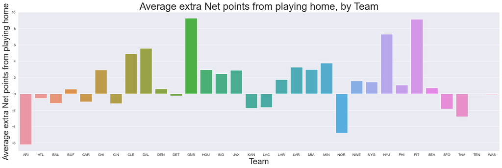

```python
#Visualizing the extra net points by team to see if home or away affects teams differently

plt.figure(figsize = (24,7))
a = sns.barplot(data = team_score_stats, x = team_score_stats.index, y = 'extra_net_points');
a.set_ylabel('Average extra Net points from playing home', fontsize=22.5);
a.set_xlabel('Team', fontsize=23)
a.set_title('Average extra Net points from playing home, by Team', fontsize= 28)
;
```

```python
#seeing the  details
team_score_stats.describe()
```

| home_or_away | away | home | extra_net_points |
| --- | --- | --- | --- |
| count | 32.000000 | 32.000000 | 32.000000 |
| mean | -0.829228 | 0.487902 | 1.317130 |
| std | 5.865277 | 5.135998 | 3.503844 |
| min | -13.750000 | -8.520000 | -6.214744 |
| 25% | -4.820000 | -3.684829 | -1.015962 |
| 50% | -0.868234 | 0.520000 | 0.917863 |
| 75% | 3.446937 | 4.644231 | 2.965513 |
| max | 8.416667 | 9.571429 | 9.263736 |

##### 2.1.3.1 What can we say are in common about teams that benefit more from playing home/away than others?

```python
#aggregated data so that it doesn't lose the other statistics
stats_by_team = ag_stats_sum.reset_index(level = [0,1]).groupby(['team']).mean()
stats_by_team['extra_net_points'] = team_score_stats['extra_net_points']
```

In the next code block, we will see the variables for a team that are most associated with a team having higher net points from playing home.

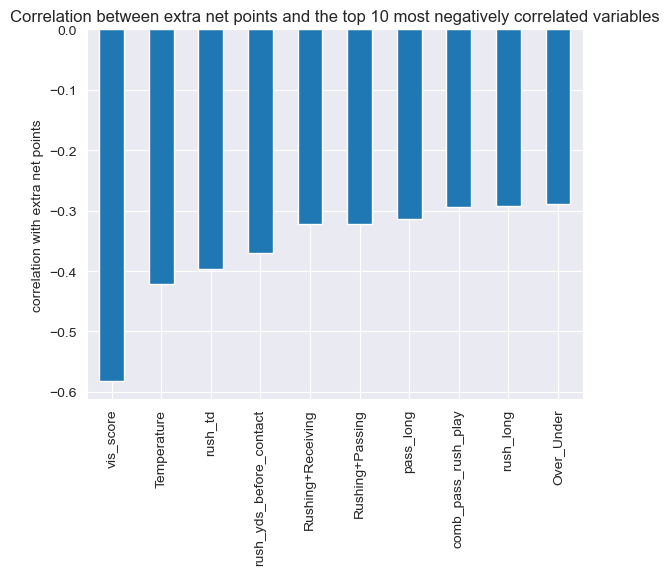

```python
#the ten variables most negatively associated with 'extra_net_points'
    # If these variables are low for a team, it means that the team will likely perform significantly better at home
stats_by_team.corrwith(stats_by_team['extra_net_points']).sort_values().head(10).plot(kind='bar')
plt.ylabel('correlation with extra net points');
plt.title('Correlation between extra net points and the top 10 most negatively correlated variables');
```

Note that almost all of the above variables are associated with better offensive performance.

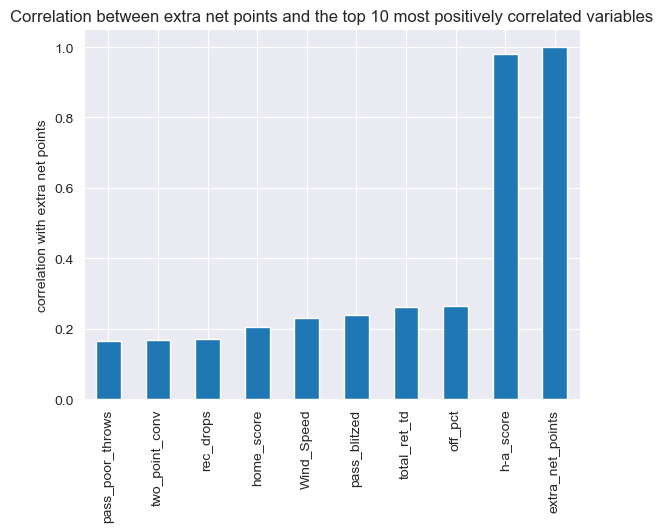

```python
#the ten variables most positively associated with 'extra_net_points'
    #if these variables are high for a team, it means that the team will likely perform significantly better at home
stats_by_team.corrwith(stats_by_team['extra_net_points']).sort_values().tail(10).plot(kind='bar')
plt.ylabel('correlation with extra net points');
plt.title('Correlation between extra net points and the top 10 most positively correlated variables');
```

Note that a lot of the above variables are associated with worse offensive performance.

### 2.2 Analysis 2

*By Will Krew*

In the following code, I grouped the humidity, temperature, and wind speed of each NFL game into bins. Furthermore, I found the score of each individual NFL game.

```python
game_humidity = data.Humidity.groupby(data.game_id).mean() # humidity for each game
binned_game_humidity = pd.cut(game_humidity,bins = 8,retbins=True) # binning humidity for each game

game_wind_speed = data.Wind_Speed.groupby(data.game_id).mean() # wind speed for each game
binned_game_wind_speed = pd.cut(game_wind_speed,bins = [-1,0,5,10,15,20,35],retbins=True) # binning wind speed for each game

game_temps = data.Temperature.groupby(data.game_id).mean() # temperature for each game
binned_game_temp = pd.cut(game_temps,bins = [5,17,29,41,53,65,75,85,95],retbins=True) # binning temperature for each game

game_scores = data.score.groupby(data.game_id).mean() # score of each game
```

In the following code, I split the data by the four main offensive positions (QB,WR,RB,TE), and then I found the total offensive fantasy points by position for each team during each game.

```python
qb_data = data.loc[data['position']=='QB',:] #creating dataset for just QB data
qb_Off_SDP = qb_data.Off_SDP.groupby(qb_data.game_id).sum() # QB Offensive Fantasy Points for each unique game + team combination

wr_data = data.loc[data['position']=='WR',:] #creating dataset for just WR data
wr_Off_SDP = wr_data.Off_SDP.groupby(wr_data.game_id).sum() # WR Offensive Fantasy Points for each unique game + team combination

rb_data = data.loc[data['position'].isin(['RB','HB']),:] #creating dataset for just RB data (note, HBs are a special characterization of RBs, which is why they are grouped together)
rb_Off_SDP = rb_data.Off_SDP.groupby(rb_data.game_id).sum() # RB Offensive Fantasy Points for each unique game + team combination

te_data = data.loc[data['position']=='TE',:] #creating dataset for just TE data
te_Off_SDP = te_data.Off_SDP.groupby(te_data.game_id).sum() # TE Offensive Fantasy Points for each unique game + team combination
```

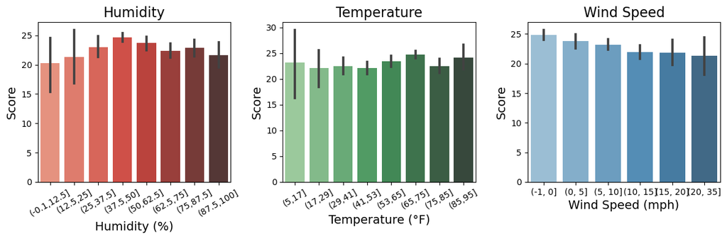

```python
# Overall Offensive Performance Plots

fig, axs = plt.subplots(1,3, figsize=(12, 4))
labels = ['(-0.1,12.5]','(12.5,25]','(25,37.5]','(37.5,50]','(50,62.5]','(62.5,75]','(75,87.5]','(87.5,100]']
labels1 = ['(5,17]','(17,29]','(29,41]','(41,53]','(53,65]','(65,75]','(75,85]','(85,95]']
# Plot for Humidity
pal_humidity = sns.color_palette("Reds_d", 8)
sns.barplot(x=binned_game_humidity[0], y=game_scores, palette=pal_humidity, ax=axs[0])
axs[0].set_xlabel(xlabel='Humidity (%)', fontsize=14)
axs[0].set_ylabel(ylabel='Score', fontsize=14)
axs[0].set_title('Humidity', fontsize=16)
axs[0].set_xticklabels(labels, rotation=30)

# Plot for Temperature
pal_temp = sns.color_palette("Greens_d", 8)
sns.barplot(x=binned_game_temp[0], y=game_scores, palette=pal_temp, ax=axs[1])
axs[1].set_xlabel(xlabel= 'Temperature (°F)', fontsize=14)
axs[1].set_ylabel(ylabel='Score', fontsize=14)
axs[1].set_title('Temperature', fontsize=16)
axs[1].set_xticklabels(labels1, rotation=30)

# Plot for Wind Speed
pal_wind_speed = sns.color_palette("Blues_d", 8)
sns.barplot(x=binned_game_wind_speed[0], y=game_scores, palette=pal_wind_speed, ax=axs[2])
axs[2].set_xlabel(xlabel='Wind Speed (mph)', fontsize=14)
axs[2].set_ylabel(ylabel='Score', fontsize=14)
axs[2].set_title('Wind Speed', fontsize=16)

plt.tight_layout()
plt.show()
```

```python
# Mean score by humidity bin
game_scores.groupby(binned_game_humidity[0]).mean()
```

```
Humidity
(-0.1, 12.5]     20.242642
(12.5, 25.0]     21.310978
(25.0, 37.5]     22.994924
(37.5, 50.0]     24.660436
(50.0, 62.5]     23.664920
(62.5, 75.0]     22.365813
(75.0, 87.5]     22.840160
(87.5, 100.0]    21.672792
Name: score, dtype: float64
```

```python
# Mean score by temperature bin
game_scores.groupby(binned_game_temp[0]).mean()
```

```
Temperature
(5, 17]     23.203623
(17, 29]    22.152219
(29, 41]    22.528318
(41, 53]    22.134879
(53, 65]    23.431646
(65, 75]    24.780282
(75, 85]    22.531105
(85, 95]    24.110113
Name: score, dtype: float64
```

```python
# Mean score by wind speed bin
game_scores.groupby(binned_game_wind_speed[0]).mean()
```

```
Wind_Speed
(-1, 0]     24.887324
(0, 5]      23.845015
(5, 10]     23.228018
(10, 15]    21.894769
(15, 20]    21.851006
(20, 35]    21.371855
Name: score, dtype: float64
```

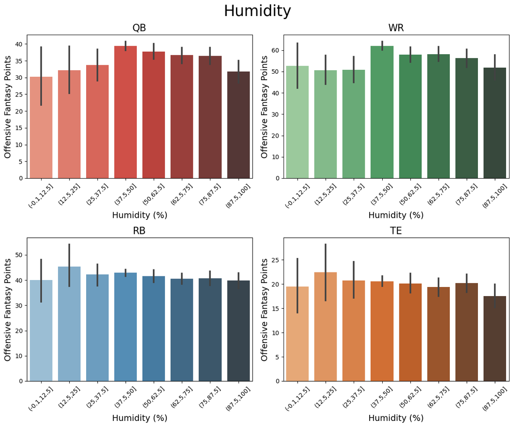

```python
# Humidity Positional Plots

fig, axs = plt.subplots(2, 2, figsize=(12, 10))
labels = ['(-0.1,12.5]','(12.5,25]','(25,37.5]','(37.5,50]','(50,62.5]','(62.5,75]','(75,87.5]','(87.5,100]']
fig.suptitle('Humidity', fontsize=25)

# Plot for QB
pal_qb = sns.color_palette("Reds_d", 8)
sns.barplot(x=binned_game_humidity[0], y=qb_Off_SDP, palette=pal_qb, ax=axs[0, 0])
axs[0, 0].set_xlabel(xlabel='Humidity (%)', fontsize=14)
axs[0, 0].set_ylabel(ylabel='Offensive Fantasy Points', fontsize=14)
axs[0, 0].set_title('QB', fontsize=16)
axs[0, 0].set_xticklabels(labels, rotation=45)

# Plot for WR
pal_wr = sns.color_palette("Greens_d", 8)
sns.barplot(x=binned_game_humidity[0], y=wr_Off_SDP, palette=pal_wr, ax=axs[0, 1])
axs[0, 1].set_xlabel(xlabel='Humidity (%)', fontsize=14)
axs[0, 1].set_ylabel(ylabel='Offensive Fantasy Points', fontsize=14)
axs[0, 1].set_title('WR', fontsize=16)
axs[0, 1].set_xticklabels(labels, rotation=45)

# Plot for RB
pal_rb = sns.color_palette("Blues_d", 8)
sns.barplot(x=binned_game_humidity[0], y=rb_Off_SDP, palette=pal_rb, ax=axs[1, 0])
axs[1, 0].set_xlabel(xlabel='Humidity (%)', fontsize=14)
axs[1, 0].set_ylabel(ylabel='Offensive Fantasy Points', fontsize=14)
axs[1, 0].set_title('RB', fontsize=16)
axs[1, 0].set_xticklabels(labels, rotation=45)

# Plot for TE
pal_te = sns.color_palette("Oranges_d", 8)
sns.barplot(x=binned_game_humidity[0], y=te_Off_SDP, palette=pal_te, ax=axs[1, 1])
axs[1, 1].set_xlabel(xlabel='Humidity (%)', fontsize=14)
axs[1, 1].set_ylabel(ylabel='Offensive Fantasy Points', fontsize=14)
axs[1, 1].set_title('TE', fontsize=16)
axs[1, 1].set_xticklabels(labels, rotation=45)

plt.tight_layout()
plt.show()
```

```python
# Mean QB offensive fantasy points by humidity bin
qb_Off_SDP.groupby(binned_game_humidity[0]).mean()
```

```
Humidity
(-0.1, 12.5]     30.252500
(12.5, 25.0]     32.206667
(25.0, 37.5]     33.696667
(37.5, 50.0]     39.458939
(50.0, 62.5]     37.696667
(62.5, 75.0]     36.693030
(75.0, 87.5]     36.423614
(87.5, 100.0]    31.732609
Name: Off_SDP, dtype: float64
```

```python
# Mean WR offensive fantasy points by humidity bin
wr_Off_SDP.groupby(binned_game_humidity[0]).mean()
```

```
Humidity
(-0.1, 12.5]     52.687500
(12.5, 25.0]     50.558333
(25.0, 37.5]     50.816667
(37.5, 50.0]     61.989231
(50.0, 62.5]     57.939848
(62.5, 75.0]     58.127879
(75.0, 87.5]     56.204337
(87.5, 100.0]    51.753043
Name: Off_SDP, dtype: float64
```

```python
# Mean RB offensive fantasy points by humidity bin
rb_Off_SDP.groupby(binned_game_humidity[0]).mean()
```

```
Humidity
(-0.1, 12.5]     39.962500
(12.5, 25.0]     45.433333
(25.0, 37.5]     42.256667
(37.5, 50.0]     42.912838
(50.0, 62.5]     41.587879
(62.5, 75.0]     40.541061
(75.0, 87.5]     40.634940
(87.5, 100.0]    39.823913
Name: Off_SDP, dtype: float64
```

```python
# Mean TE offensive fantasy points by humidity bin
te_Off_SDP.groupby(binned_game_humidity[0]).mean()
```

```
Humidity
(-0.1, 12.5]     19.492500
(12.5, 25.0]     22.433333
(25.0, 37.5]     20.753333
(37.5, 50.0]     20.592520
(50.0, 62.5]     20.124242
(62.5, 75.0]     19.381818
(75.0, 87.5]     20.192530
(87.5, 100.0]    17.521739
Name: Off_SDP, dtype: float64
```

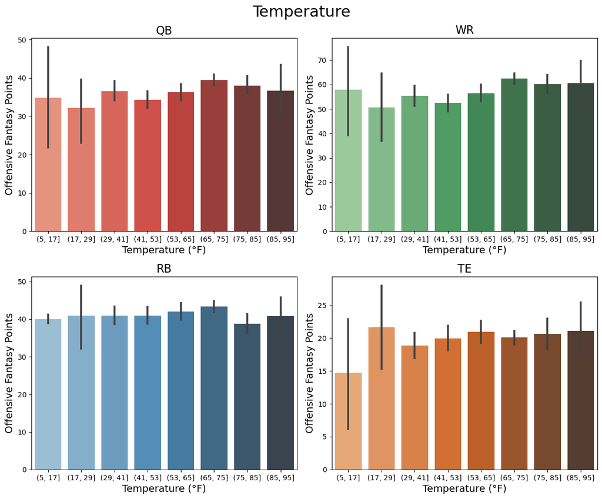

```python
# Temperature Positional Plots

fig, axs = plt.subplots(2, 2, figsize=(12, 10))
fig.suptitle('Temperature', fontsize=22)

# Plot for QB
pal_qb = sns.color_palette("Reds_d", 8)
sns.barplot(x=binned_game_temp[0], y=qb_Off_SDP, palette=pal_qb, ax=axs[0, 0])
axs[0, 0].set_xlabel(xlabel='Temperature (°F)', fontsize=14)
axs[0, 0].set_ylabel(ylabel='Offensive Fantasy Points', fontsize=14)
axs[0, 0].set_title('QB', fontsize=16)

# Plot for WR
pal_wr = sns.color_palette("Greens_d", 8)
sns.barplot(x=binned_game_temp[0], y=wr_Off_SDP, palette=pal_wr, ax=axs[0, 1])
axs[0, 1].set_xlabel(xlabel='Temperature (°F)', fontsize=14)
axs[0, 1].set_ylabel(ylabel='Offensive Fantasy Points', fontsize=14)
axs[0, 1].set_title('WR', fontsize=16)

# Plot for RB
pal_rb = sns.color_palette("Blues_d", 8)
sns.barplot(x=binned_game_temp[0], y=rb_Off_SDP, palette=pal_rb, ax=axs[1, 0])
axs[1, 0].set_xlabel(xlabel='Temperature (°F)', fontsize=14)
axs[1, 0].set_ylabel(ylabel='Offensive Fantasy Points', fontsize=14)
axs[1, 0].set_title('RB', fontsize=16)

# Plot for TE
pal_te = sns.color_palette("Oranges_d", 8)
sns.barplot(x=binned_game_temp[0], y=te_Off_SDP, palette=pal_te, ax=axs[1, 1])
axs[1, 1].set_xlabel(xlabel='Temperature (°F)', fontsize=14)
axs[1, 1].set_ylabel(ylabel='Offensive Fantasy Points', fontsize=14)
axs[1, 1].set_title('TE', fontsize=16)

plt.tight_layout()
plt.show()
```

```python
# Mean QB offensive fantasy points by temperature bin
qb_Off_SDP.groupby(binned_game_temp[0]).mean()
```

```
Temperature
(5, 17]     34.828000
(17, 29]    32.157500
(29, 41]    36.505053
(41, 53]    34.360702
(53, 65]    36.343206
(65, 75]    39.470966
(75, 85]    38.048723
(85, 95]    36.661905
Name: Off_SDP, dtype: float64
```

```python
# Mean WR offensive fantasy points by temperature bin
wr_Off_SDP.groupby(binned_game_temp[0]).mean()
```

```
Temperature
(5, 17]     57.820000
(17, 29]    50.575000
(29, 41]    55.478316
(41, 53]    52.536667
(53, 65]    56.554504
(65, 75]    62.469432
(75, 85]    60.252979
(85, 95]    60.676190
Name: Off_SDP, dtype: float64
```

```python
# Mean RB offensive fantasy points by temperature bin
rb_Off_SDP.groupby(binned_game_temp[0]).mean()
```

```
Temperature
(5, 17]     40.000000
(17, 29]    40.950000
(29, 41]    40.929474
(41, 53]    40.967719
(53, 65]    41.967939
(65, 75]    43.365625
(75, 85]    38.830213
(85, 95]    40.838095
Name: Off_SDP, dtype: float64
```

```python
# Mean TE offensive fantasy points by temperature bin
te_Off_SDP.groupby(binned_game_temp[0]).mean()
```

```
Temperature
(5, 17]     14.680000
(17, 29]    21.650000
(29, 41]    18.839789
(41, 53]    19.950000
(53, 65]    20.919084
(65, 75]    20.091818
(75, 85]    20.643617
(85, 95]    21.142857
Name: Off_SDP, dtype: float64
```

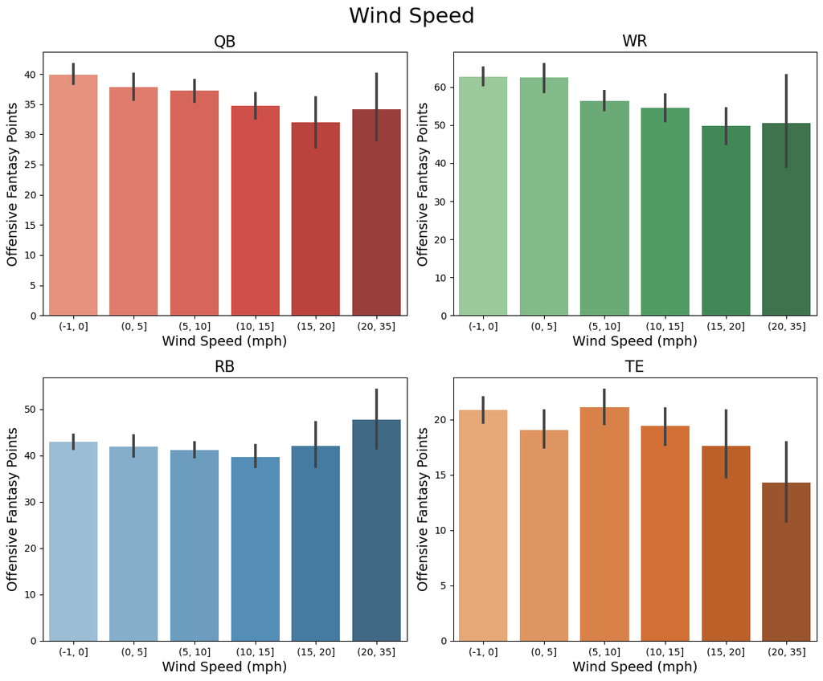

```python
# Wind Speed Positional Plots

fig, axs = plt.subplots(2, 2, figsize=(12, 10))
fig.suptitle('Wind Speed', fontsize=22)

# Plot for QB
pal_qb = sns.color_palette("Reds_d", 8)
sns.barplot(x=binned_game_wind_speed[0], y=qb_Off_SDP, palette=pal_qb, ax=axs[0, 0])
axs[0, 0].set_xlabel(xlabel='Wind Speed (mph)', fontsize=14)
axs[0, 0].set_ylabel(ylabel='Offensive Fantasy Points', fontsize=14)
axs[0, 0].set_title('QB', fontsize=16)

# Plot for WR
pal_wr = sns.color_palette("Greens_d", 8)
sns.barplot(x=binned_game_wind_speed[0], y=wr_Off_SDP, palette=pal_wr, ax=axs[0, 1])
axs[0, 1].set_xlabel(xlabel='Wind Speed (mph)', fontsize=14)
axs[0, 1].set_ylabel(ylabel='Offensive Fantasy Points', fontsize=14)
axs[0, 1].set_title('WR', fontsize=16)

# Plot for RB
pal_rb = sns.color_palette("Blues_d", 8)
sns.barplot(x=binned_game_wind_speed[0], y=rb_Off_SDP, palette=pal_rb, ax=axs[1, 0])
axs[1, 0].set_xlabel(xlabel='Wind Speed (mph)', fontsize=14)
axs[1, 0].set_ylabel(ylabel='Offensive Fantasy Points', fontsize=14)
axs[1, 0].set_title('RB', fontsize=16)

# Plot for TE
pal_te = sns.color_palette("Oranges_d", 8)
sns.barplot(x=binned_game_wind_speed[0], y=te_Off_SDP, palette=pal_te, ax=axs[1, 1])
axs[1, 1].set_xlabel(xlabel='Wind Speed (mph)', fontsize=14)
axs[1, 1].set_ylabel(ylabel='Offensive Fantasy Points', fontsize=14)
axs[1, 1].set_title('TE', fontsize=16)

plt.tight_layout()
plt.show()
```

```python
# Mean QB offensive fantasy points by wind speed bin
qb_Off_SDP.groupby(binned_game_wind_speed[0]).mean()
```

```
Wind_Speed
(-1, 0]     39.905906
(0, 5]      37.846718
(5, 10]     37.201887
(10, 15]    34.741709
(15, 20]    31.960435
(20, 35]    34.130000
Name: Off_SDP, dtype: float64
```

```python
# Mean WR offensive fantasy points by wind speed bin
wr_Off_SDP.groupby(binned_game_wind_speed[0]).mean()
```

```
Wind_Speed
(-1, 0]     62.723289
(0, 5]      62.444427
(5, 10]     56.346415
(10, 15]    54.490940
(15, 20]    49.718261
(20, 35]    50.593750
Name: Off_SDP, dtype: float64
```

```python
# Mean RB offensive fantasy points by wind speed bin
rb_Off_SDP.groupby(binned_game_wind_speed[0]).mean()
```

```
Wind_Speed
(-1, 0]     42.901745
(0, 5]      41.952214
(5, 10]     41.164434
(10, 15]    39.736239
(15, 20]    42.108696
(20, 35]    47.681250
Name: Off_SDP, dtype: float64
```

```python
# Mean TE offensive fantasy points by wind speed bin
te_Off_SDP.groupby(binned_game_wind_speed[0]).mean()
```

```
Wind_Speed
(-1, 0]     20.849597
(0, 5]      19.080458
(5, 10]     21.136226
(10, 15]    19.441880
(15, 20]    17.623913
(20, 35]    14.306250
Name: Off_SDP, dtype: float64
```

```python
# percent of games in each humidity bin
binned_game_humidity[0].value_counts()/len(binned_game_humidity[0])
```

```
(37.5, 50.0]     0.459756
(50.0, 62.5]     0.160976
(62.5, 75.0]     0.160976
(75.0, 87.5]     0.101220
(87.5, 100.0]    0.056098
(25.0, 37.5]     0.036585
(12.5, 25.0]     0.014634
(-0.1, 12.5]     0.009756
Name: Humidity, dtype: float64
```

```python
# percent of games in each temperature bin
binned_game_temp[0].value_counts()/len(binned_game_temp[0])
```

```
(65, 75]    0.429268
(53, 65]    0.159756
(41, 53]    0.139024
(29, 41]    0.115854
(75, 85]    0.114634
(85, 95]    0.025610
(17, 29]    0.009756
(5, 17]     0.006098
Name: Temperature, dtype: float64
```

```python
# percent of games in each wind speed bin
binned_game_wind_speed[0].value_counts()/len(binned_game_wind_speed[0])
```

```
(-1, 0]     0.363415
(5, 10]     0.258537
(0, 5]      0.159756
(10, 15]    0.142683
(15, 20]    0.056098
(20, 35]    0.019512
Name: Wind_Speed, dtype: float64
```

```python
# Total number of games
len(game_scores)
```

```
820
```

```python
# Games where all 3 weather variables are suboptimal
(((game_temps<=53)&(game_wind_speed>10))&((game_humidity<=37.5)|(game_humidity>62.5))).sum()
```

```
45
```

```python
# Games where exactly 2 weather variables are suboptimal
(((game_temps>53)&(game_wind_speed>10))&((game_humidity<=37.5)|(game_humidity>62.5))).sum() \
+ (((game_temps<=53)&(game_wind_speed<=10))&((game_humidity<=37.5)|(game_humidity>62.5))).sum() \
+ (((game_temps<=53)&(game_wind_speed>10))&((game_humidity>37.5)&(game_humidity<=62.5))).sum()
```

```
175
```

```python
# Games where exactly 1 weather variable is suboptimal
(((game_temps>53)&(game_wind_speed<=10))&((game_humidity<=37.5)|(game_humidity>62.5))).sum() \
+ (((game_temps>53)&(game_wind_speed>10))&((game_humidity>37.5)&(game_humidity<=62.5))).sum() \
+ (((game_temps<=53)&(game_wind_speed<=10))&((game_humidity>37.5)&(game_humidity<=62.5))).sum()
```

```
227
```

```python
# Games where exactly 0 weather variables are suboptimal
(((game_temps>53)&(game_wind_speed<=10))&((game_humidity>37.5)&(game_humidity<=62.5))).sum()
```

```
373
```

```python
# Games where at least 1 weather variable is suboptimal
(((game_temps<=53)|(game_wind_speed>10))|((game_humidity<=37.5)|(game_humidity>62.5))).sum()
```

```
447
```

### 2.3 Analysis 3

*By Daniel Gold*

Creating a Dataframe to store the surface for each game

```python
#creates a list of the unqiue game_ids, which represent each game in the dataset
allGames=data.game_id.value_counts().index
#converts the list into a series
allGames=pd.Series(allGames)
#makes a series containing the surface of the game with the corresponding index in allGames
surfaces=allGames.apply(lambda x: data.loc[data.game_id==x].Surface.mode())
#concatenates the surfaces and allGames series to create a dataframe
gamesSurface=pd.concat([surfaces,allGames], axis=1)
```

#### 2.3.1 TOTAL YARDS

##### 2.3.1.1 Barplot

```python
#makes a series containing the total yards of the game with the corresponding index in allGames
totalYards=allGames.apply(lambda x: data.loc[data.game_id==x]['Rushing+Passing'].sum())
#creates a dataframe containing the surface and total yards for each game, and renames the columns to match what each column stores
allYardsDF=pd.concat([gamesSurface,totalYards], axis=1)
allYardsDF.columns = ['Surface', 'game_id', 'total_yards']
```

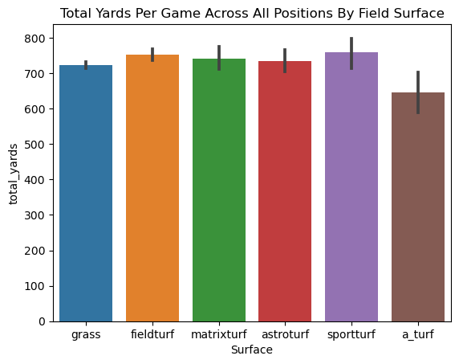

```python
#use seaborn to create a barplot to show the comparison of means of total yards per game across surfaces
sns.barplot(y=allYardsDF.total_yards, x=allYardsDF.Surface)
#adding the title
plt.title('Total Yards Per Game Across All Positions By Field Surface')
```

###### 2.3.1.1.1 Density Plot

```python
#subset the data by each surface and then groupby the game ID to be able to sum the yards for each game
totalGrassYards=data.loc[data.Surface=='grass'].groupby('game_id')['Rushing+Passing'].sum()
totalFturfYards=data.loc[data.Surface=='fieldturf'].groupby('game_id')['Rushing+Passing'].sum()
totalASturfYards=data.loc[data.Surface=='astroturf'].groupby('game_id')['Rushing+Passing'].sum()
totalMturfYards=data.loc[data.Surface=='matrixturf'].groupby('game_id')['Rushing+Passing'].sum()
totalSturfYards=data.loc[data.Surface=='sportturf'].groupby('game_id')['Rushing+Passing'].sum()
totalAturfYards=data.loc[data.Surface=='a_turf'].groupby('game_id')['Rushing+Passing'].sum()
#each of these is an object that stores the total yards for each game_id
```

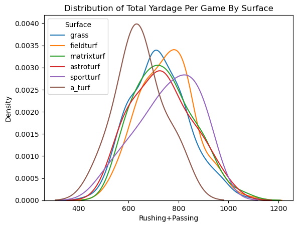

```python
#use kdeplot to plot the density distribution of the yardage for each surface
sns.kdeplot(x=totalGrassYards)
sns.kdeplot(x=totalFturfYards)
sns.kdeplot(x=totalMturfYards)
sns.kdeplot(x=totalASturfYards)
sns.kdeplot(x=totalSturfYards)
sns.kdeplot(x=totalAturfYards)
plt.legend(title='Surface', loc='upper left', labels=['grass', 'fieldturf', 'matrixturf', 'astroturf', 'sportturf', 'a_turf'])
plt.title('Distribution of Total Yardage Per Game By Surface')
```

##### 2.3.1.2 Additional Calculations

```python
#creates a series with the total yards for all types of turf
allYardsAllTurf=pd.concat([totalFturfYards,totalASturfYards,totalMturfYards,totalSturfYards,totalAturfYards], axis=0)
#stores the average yards per game across all types of turfs
avgTurfYdsTotal=allYardsAllTurf.mean()
#calculates the perecent increase in total yards per game from playing on grass to playing on turf
((avgTurfYdsTotal-totalGrassYards.mean())/totalGrassYards.mean())*100
```

```
3.025060081979486
```

```python
#the summary statistics for the total yards per game across all turf fields
allYardsAllTurf.describe()
```

```
count     323.000000
mean      745.306502
std       114.622343
min       485.000000
25%       659.000000
50%       745.000000
75%       825.500000
max      1096.000000
Name: Rushing+Passing, dtype: float64
```

```python
#the summary statistics for total yards per game on grass fields
totalGrassYards.describe()
```

```
count     497.000000
mean      723.422535
std       116.544011
min       420.000000
25%       637.000000
50%       716.000000
75%       800.000000
max      1107.000000
Name: Rushing+Passing, dtype: float64
```

#### 2.3.2 QUARTERBACKS

###### 2.3.2.0.1 Barplots

```python
#made a subset of the data only containing quarterbacks
quarterBacks=data[data.position=='QB']
```

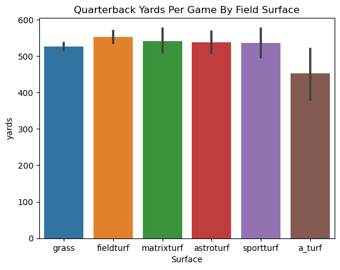

```python
#makes a series containing the total quarterback yards of the game with the corresponding index in allGames
totalYardsQB=allGames.apply(lambda x: quarterBacks.loc[quarterBacks.game_id==x]['Rushing+Passing'].sum())
#creates a new dataframe storing the surface and total qb yards for each game
qbDF=pd.concat([gamesSurface, totalYardsQB], axis=1)
#renames the columns top match the content in each column
qbDF.columns = ['Surface', 'game_id', 'yards']
#use seaborn to create a barplot to show the comparison of means of total yards per game across surfaces
sns.barplot(x=qbDF.Surface, y=qbDF.yards)
#adding the title
plt.title('Quarterback Yards Per Game By Field Surface')
```

##### 2.3.2.1 Density Plot

```python
#subset the quarterback dataframe by each surface and then groupby the game ID to be able to sum the yards for each game
qbGrassYards=quarterBacks.loc[quarterBacks.Surface=='grass'].groupby('game_id')['Rushing+Passing'].sum()
qbFturfYards=quarterBacks.loc[quarterBacks.Surface=='fieldturf'].groupby('game_id')['Rushing+Passing'].sum()
qbASturfYards=quarterBacks.loc[quarterBacks.Surface=='astroturf'].groupby('game_id')['Rushing+Passing'].sum()
qbMturfYards=quarterBacks.loc[quarterBacks.Surface=='matrixturf'].groupby('game_id')['Rushing+Passing'].sum()
qbSturfYards=quarterBacks.loc[quarterBacks.Surface=='sportturf'].groupby('game_id')['Rushing+Passing'].sum()
qbAturfYards=quarterBacks.loc[quarterBacks.Surface=='a_turf'].groupby('game_id')['Rushing+Passing'].sum()
#each of these is an object that stores the total quarterback yards for each game_id
```

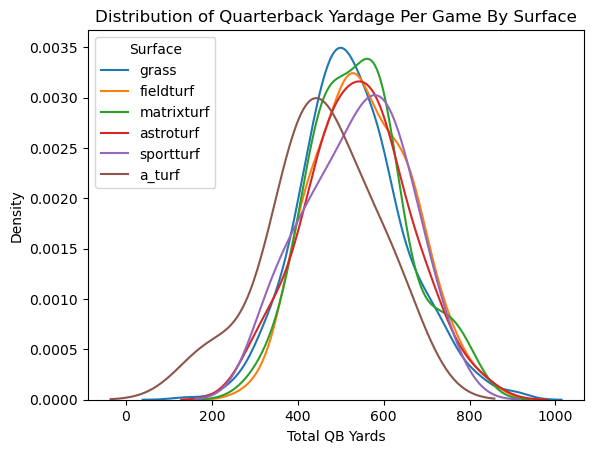

```python
#use kdeplot to plot the density distribution of the yardage for each surface
sns.kdeplot(x=qbGrassYards)
sns.kdeplot(x=qbFturfYards)
sns.kdeplot(x=qbMturfYards)
sns.kdeplot(x=qbASturfYards)
sns.kdeplot(x=qbSturfYards)
sns.kdeplot(x=qbAturfYards)
plt.legend(title='Surface', loc='upper left', labels=['grass', 'fieldturf', 'matrixturf', 'astroturf', 'sportturf', 'a_turf'])
plt.title('Distribution of Quarterback Yardage Per Game By Surface')
plt.xlabel('Total QB Yards')
```

##### 2.3.2.2 Additional Calculations

```python
#creates a series with the quarterback yards per game for all types of turf
qbYardsAllTurf=pd.concat([qbFturfYards,qbASturfYards,qbMturfYards,qbSturfYards,qbAturfYards], axis=0)
#stores the average qb yards per game across all types of turfs
avgTurfYdsQB=qbYardsAllTurf.mean()
#calculates the perecent increase in qb yards per game from playing on grass to playing on turf
((avgTurfYdsQB-qbGrassYards.mean())/qbGrassYards.mean())*100
```

```
3.346045783516028
```

```python
#the summary statistics for the qb yards per game across all turf fields
qbYardsAllTurf.describe()
```

```
count    323.000000
mean     544.074303
std      113.245655
min      200.000000
25%      459.500000
50%      540.000000
75%      620.500000
max      850.000000
Name: Rushing+Passing, dtype: float64
```

```python
#the summary statistics for qb yards per game on grass fields
qbGrassYards.describe()
```

```
count    497.000000
mean     526.458753
std      118.895398
min      142.000000
25%      450.000000
50%      518.000000
75%      597.000000
max      911.000000
Name: Rushing+Passing, dtype: float64
```

#### 2.3.3 RUNNING BACKS

##### 2.3.3.1 Barplots

```python
#made a subset of the data only containing runningbacks
runningBacks=data.loc[data.position.isin(['RB', 'HB'])].copy()

#added a column that stores the sum of the rushing and receiving yards for each running back
runningBacks=runningBacks.rename(columns={'Rushing+Receiving':'Total RB Yards'})
```

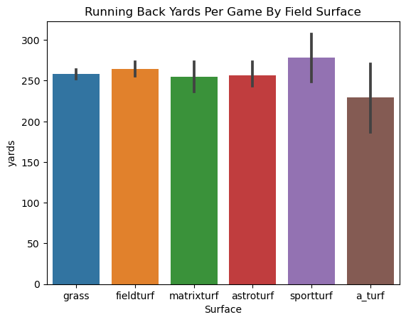

```python
#makes a series containing the total runningback yards of the game with the corresponding index in allGames
totalYardsRB=allGames.apply(lambda x: runningBacks.loc[runningBacks.game_id==x]['Total RB Yards'].sum())
#creates a new dataframe storing the surface and total running back yards for each game
rbDF=pd.concat([gamesSurface, totalYardsRB], axis=1)
#renames the columns top match the content in each column
rbDF.columns = ['Surface', 'game_id', 'yards']
#use seaborn to create a barplot to show the comparison of means of total runningback yards per game across surfaces
sns.barplot(x=rbDF.Surface, y=rbDF.yards)
plt.title('Running Back Yards Per Game By Field Surface')
```

###### 2.3.3.1.1 Density Plots

```python
#subset the runningback dataframe by each surface and then groupby the game ID to be able to sum the yards for each game
rbGrassYards=runningBacks.loc[runningBacks.Surface=='grass'].groupby('game_id')['Total RB Yards'].sum()
rbFturfYards=runningBacks.loc[runningBacks.Surface=='fieldturf'].groupby('game_id')['Total RB Yards'].sum()
rbASturfYards=runningBacks.loc[runningBacks.Surface=='astroturf'].groupby('game_id')['Total RB Yards'].sum()
rbMturfYards=runningBacks.loc[runningBacks.Surface=='matrixturf'].groupby('game_id')['Total RB Yards'].sum()
rbSturfYards=runningBacks.loc[runningBacks.Surface=='sportturf'].groupby('game_id')['Total RB Yards'].sum()
rbAturfYards=runningBacks.loc[runningBacks.Surface=='a_turf'].groupby('game_id')['Total RB Yards'].sum()
#each of these is an object that stores the total runningback yards for each game_id
```

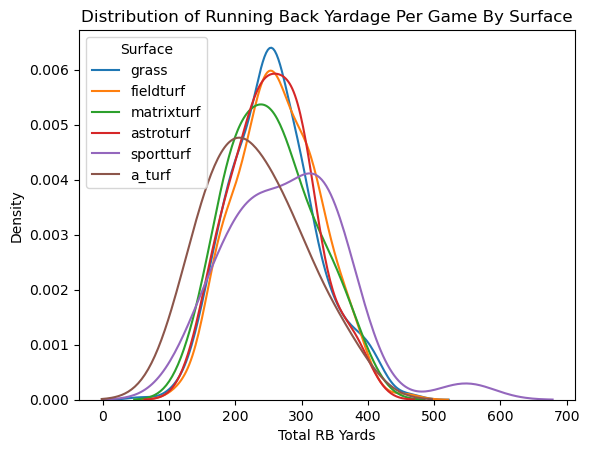

```python
#use kdeplot to plot the density distribution of the yardage for each surface
sns.kdeplot(x=rbGrassYards)
sns.kdeplot(x=rbFturfYards)
sns.kdeplot(x=rbMturfYards)
sns.kdeplot(x=rbASturfYards)
sns.kdeplot(x=rbSturfYards)
sns.kdeplot(x=rbAturfYards)
plt.legend(title='Surface', loc='upper left', labels=['grass', 'fieldturf', 'matrixturf', 'astroturf', 'sportturf', 'a_turf'])
plt.title('Distribution of Running Back Yardage Per Game By Surface')
```

##### 2.3.3.2 Additional Calculations

```python
#creates a series with the runningback yards per game for all types of turf
rbYardsAllTurf=pd.concat([rbFturfYards,rbASturfYards,rbMturfYards,rbSturfYards,rbAturfYards], axis=0)
#stores the average rb yards per game across all types of turfs
avgTurfYdsRB=rbYardsAllTurf.mean()
#calculates the perecent increase in rb yards per game from playing on grass to playing on turf
((avgTurfYdsRB-rbGrassYards.mean())/rbGrassYards.mean())*100
```

```
1.3981768413723796
```

```python
#the summary statistics for the rb yards per game across all turf fields
rbYardsAllTurf.describe()
```

```
count    323.000000
mean     262.003096
std       65.091455
min      119.000000
25%      215.500000
50%      259.000000
75%      307.000000
max      548.000000
Name: Total RB Yards, dtype: float64
```

```python
#the summary statistics for the rb yards per game on grass
rbGrassYards.describe()
```

```
count    497.000000
mean     258.390342
std       65.644360
min       57.000000
25%      211.000000
50%      255.000000
75%      298.000000
max      465.000000
Name: Total RB Yards, dtype: float64
```

#### 2.3.4 WIDE RECEIVERS/TIGHT ENDS

```python
#made a subset of the data only containing wide receivers and tight ends
wrte=data.loc[data.position.isin(['WR', 'TE'])].copy()

#added a column that stores the sum of the rushing and receiving yards for each receiver and tight end
wrte=wrte.rename(columns={'Rushing+Receiving':'Total WR/TE Yards'})
```

##### 2.3.4.1 Barplots

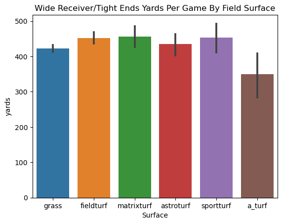

```python
#makes a series containing the total wide receiver and tight end yards of the game with the corresponding index in allGames
totalYardsWRTE=allGames.apply(lambda x: wrte.loc[wrte.game_id==x]['Total WR/TE Yards'].sum())
#creates a new dataframe storing the surface and total wide receiver and tight end yards for each game
wrteDF=pd.concat([gamesSurface, totalYardsWRTE], axis=1)
#renames the columns top match the content in each column
wrteDF.columns = ['Surface', 'game_id', 'yards']
#use seaborn to create a barplot to show the comparison of means of total wide receiver and tight end yards per game across surfaces
sns.barplot(x=wrteDF.Surface, y=wrteDF.yards)
plt.title('Wide Receiver/Tight Ends Yards Per Game By Field Surface')
```

##### 2.3.4.2 Density Plots

```python
#subset the receiver and tight end dataframe by each surface and then groupby the game ID to be able to sum the yards for each game
wrteGrassYards=wrte.loc[wrte.Surface=='grass'].groupby('game_id')['Total WR/TE Yards'].sum()
wrteFturfYards=wrte.loc[wrte.Surface=='fieldturf'].groupby('game_id')['Total WR/TE Yards'].sum()
wrteMturfYards=wrte.loc[wrte.Surface=='matrixturf'].groupby('game_id')['Total WR/TE Yards'].sum()
wrteASturfYards=wrte.loc[wrte.Surface=='astroturf'].groupby('game_id')['Total WR/TE Yards'].sum()
wrteSturfYards=wrte.loc[wrte.Surface=='sportturf'].groupby('game_id')['Total WR/TE Yards'].sum()
wrteAturfYards=wrte.loc[wrte.Surface=='a_turf'].groupby('game_id')['Total WR/TE Yards'].sum()
#each of these is an object that stores the total wide receiver and tight end yards for each game_id
```

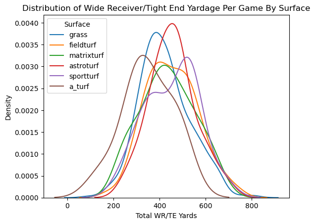

```python
#use kdeplot to plot the density distribution of the yardage for each surface
sns.kdeplot(x=wrteGrassYards)
sns.kdeplot(x=wrteFturfYards)
sns.kdeplot(x=wrteASturfYards)
sns.kdeplot(x=wrteMturfYards)
sns.kdeplot(x=wrteSturfYards)
sns.kdeplot(x=wrteAturfYards)
plt.legend(title='Surface', loc='upper left', labels=['grass', 'fieldturf', 'matrixturf', 'astroturf', 'sportturf', 'a_turf'])
plt.title('Distribution of Wide Receiver/Tight End Yardage Per Game By Surface')
```

##### 2.3.4.3 Additional Calculations

```python
#creates a series with the wr/te yards per game for all types of turf
wrteYardsAllTurf=pd.concat([wrteFturfYards,wrteASturfYards,wrteMturfYards,wrteSturfYards,wrteAturfYards], axis=0)
#stores the average wr/te yards per game across all types of turfs
avgTurfYdsWRTE=wrteYardsAllTurf.mean()
#calculates the perecent increase in wr/te yards per game from playing on grass to playing on turf
((avgTurfYdsWRTE-wrteGrassYards.mean())/wrteGrassYards.mean())*100
```

```
5.730916068410202
```

```python
#the summary statistics for the wr/te yards per game across all turf fields
wrteYardsAllTurf.describe()
```

```
count    323.000000
mean     446.678019
std      112.336154
min      148.000000
25%      367.500000
50%      440.000000
75%      523.500000
max      746.000000
Name: Total WR/TE Yards, dtype: float64
```

```python
#the summary statistics for the wr/te yards per game on grass
wrteGrassYards.describe()
```

```
count    497.000000
mean     422.466801
std      111.193831
min       84.000000
25%      347.000000
50%      411.000000
75%      489.000000
max      818.000000
Name: Total WR/TE Yards, dtype: float64
```

### 2.4 Analysis 4

*By Andrew Metzger*

##### 2.4.0.1 Demographics of Teams That Win

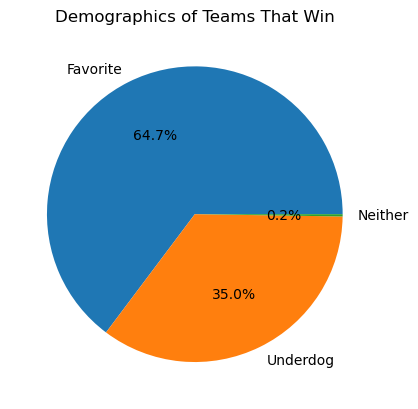

```python
#As I only need score data for each combination of game_id and team, I can group by game_id and team and take the first entry
winner_data = data[data.win=='win'].groupby(['game_id','team']).first() #Subsetting and grouping the data to the teams that won
plt.pie(winner_data.favorite.value_counts()/winner_data.favorite.value_counts().sum(),labels=['Favorite','Underdog','Neither'],autopct='%1.1f%%'); #Creating a pie chart with the proportion of winning teams that were the favorite to win
plt.title('Demographics of Teams That Win'); #Creating a title for the pie chart
```

##### 2.4.0.2 Demographics of Teams That Cover

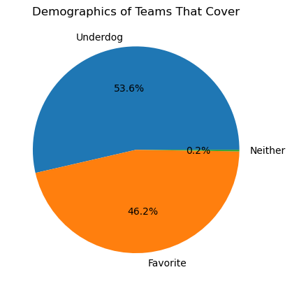

```python
#As I only need score data for each combination of game_id and team, I can group by game_id and team and take the first entry
covered_data = data[data.covered=='yes'].groupby(['game_id','team']).first() #Subsetting and grouping the data to the teams that covered
plt.pie(covered_data.favorite.value_counts()/covered_data.favorite.value_counts().sum(),labels=['Underdog','Favorite','Neither'],autopct='%1.1f%%'); #Creating a pie chart with the proportion of teams that covered that were the favorite to win
plt.title('Demographics of Teams That Cover'); #Creating a title for the pie chart
```

##### 2.4.0.3 Underdog Vegas Line vs Score Differential

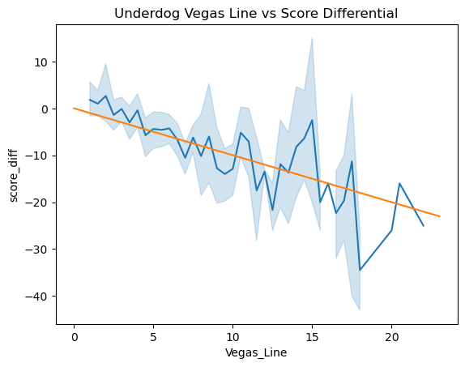

```python
#As I only need score data for each combination of game_id and team, I can group by game_id and team and take the first entry
underdog_data=data[data.favorite=='no'].groupby(['game_id','team']).first() #Subsetting and grouping the data to the teams that are projected to lose (underdogs)
sns.lineplot(data=underdog_data,x='Vegas_Line',y='score_diff'); #making a lineplot of vegas line (x axis) vs score differential (y axis)
x = np.linspace(0, 23, 100); #Defining a linespace that starts at 0 and ends at 23 with 100 samples generated
plt.plot(x,-x); #Plotting the linespace with a slope of -1 that represents the relation between vegas line and score differential if vegas was perfect at predicting the score of games (all values above the line are when the underdog covered)
plt.title('Underdog Vegas Line vs Score Differential'); #Creating a title for the line plot
```

##### 2.4.0.4 Underdog Teams Covering vs Vegas Line

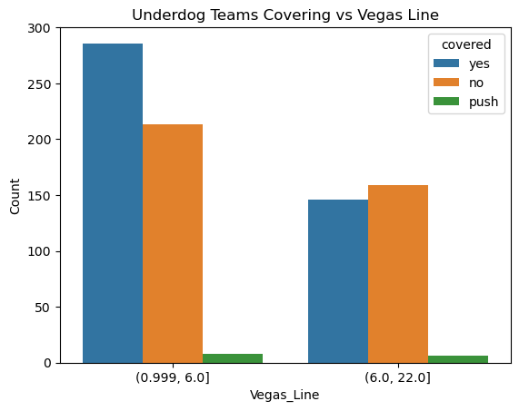

```python
binned_underdog_data = pd.cut(underdog_data.Vegas_Line,[.999,6,22],retbins=True) #Manually creating 2 bins for vegas line based on the trend identified in the lineplot above
underdog_data['Binned_Vegas_Line'] = binned_underdog_data[0] #Adding a Binned_Vegas_Line column to the underdog data that represents what bin they are in
sns.countplot(data=underdog_data,x='Binned_Vegas_Line',hue='covered'); #Creating a countplot of the number of underdog teams in each bin that cover
plt.xlabel('Vegas_Line'); #Creating a label for the x-axis
plt.ylabel('Count'); #Creating a label for the y-axis
plt.title('Underdog Teams Covering vs Vegas Line'); #Creating a title for the countplot
```

##### 2.4.0.5 1 to 6 Point Underdogs That Cover

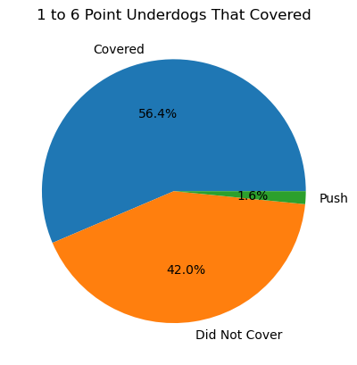

```python
#As I only need score data for each combination of game_id and team, I can group by game_id and team and take the first entry
one_to_six_underdog_data = underdog_data[underdog_data.Binned_Vegas_Line==binned_underdog_data[0].value_counts().index[0]] #Subsetting and grouping the underdog data to the teams that were between 1 and 6 point underdogs
plt.pie(one_to_six_underdog_data.covered.value_counts()/one_to_six_underdog_data.covered.value_counts().sum(),labels=['Covered','Did Not Cover','Push'],autopct='%1.1f%%'); #Creating a pie chart with the proportion of teams that are 1 to 6 point underdogs that covered
plt.title('1 to 6 Point Underdogs That Covered'); #Creating a title for the pie chart
```